# Notas Alunos - UFCG

Wesley Nunes Marques Torres / 112210480

January 15, 2016

# Introdução

### Análise das notas dos Alunos da Universidade Federal de Campina Grande(UFCG)

Este Documento tem a finalidade de analisar as notas dos cursos da UFCG verificando desempenho e relações entre elas.

> Conhecendo as variáveis relacionadas aos alunos
- **Variáveis**
  - Matricula: Número de matrícula
  - Cod_Curso: Código do curso
  - Cod_Disciplina: Código da disciplina cursada
  - Cod_Evasao: 0 se o aluno nao evadiu ao fim do primeiro periodo e 1 se ele evadiu
  - Nome_Curso: Nome do Curso
  - Periodo: Período cursado
  - Nome_Disciplina: Nome da disciplina cursada
  - Creditos: Créditos da disciplina
  - Departamento: Nome do departamento
  - Media_Disciplina: Média obtida na Disciplina
  - Situacao: Status ao na disciplina(Aprovado, Reprovado, Em curso)
  - Centro: Centro acadêmico
  - Campus: Localidade do Campus
  - Creditos_Curso: total de créditos necessários para o aluno concluir o curso
  - Tipo: Tipo da disciplina cursada(Obrigatória, Optativa …)
  - Periodo_Ingresso: Período em que a cadeira foi cursada
  - Periodo_Relativo: Total de períodos do alunos ao longo do curso

> Parte 1

### Há algo surpreendente ou estranho nos dados?

Sabendo que a mediana é uma operação mais confiável que a média para análise de dispersão dos dados, isso nós podemos perceber pelo gráfico abaixo, pois verificamos que há diferença na disperção, fazendo com que a média não mostre a verdadeira realidade dos cursos, pois há um grande intervalo entre as notas. Outro fato interessante é na consistência dos dados, causando erro na análise devido a valores inválidos nos campos de notas. Isso é causando quando um aluno tranca a disciplina, com isso não se pode avaliar o evento deste aluno de cursar a disciplina.

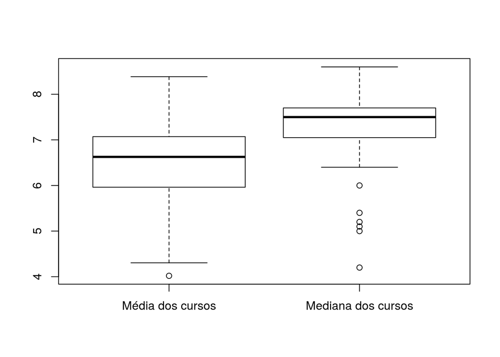

```r
boxplot(meanByCourse$x, medianByCourse$x, names = c("Média dos cursos", "Mediana dos cursos"))
```

Com o gráfico de disperção abaixo, podemos identificar a grande diferença das notas, causando outlier com valores outside, mostrados no boxsplot acima. Sabendo disso, a mediana será uma medida mais confiável para analisar os dados. Também podemos observar o quão desproporcional, estão alguns cursos, enquanto grande parte dos curso se concentram com valores >= 7, apenas 8 cursos estão fora da normalidade da mediana da universidade. Isso se torna algo estranho e que se deve analisar o porque deste ocorrido.

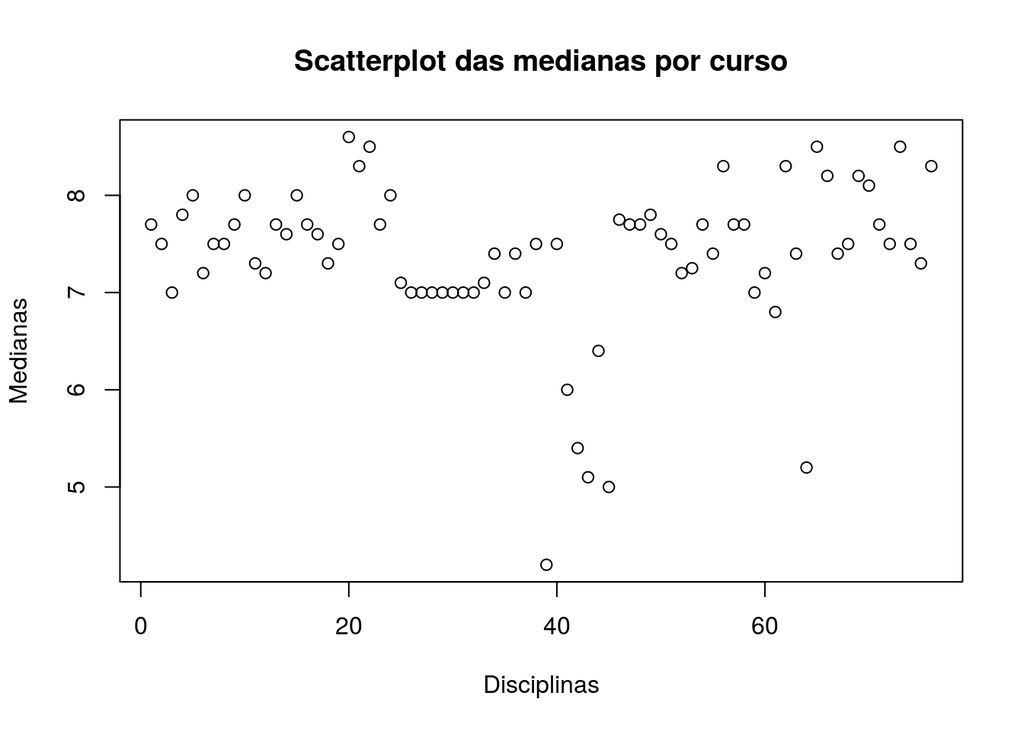

```r
plot(medianByCourse$x, main="Scatterplot das medianas por curso", xlab = "Disciplinas", ylab = "Medianas")
```

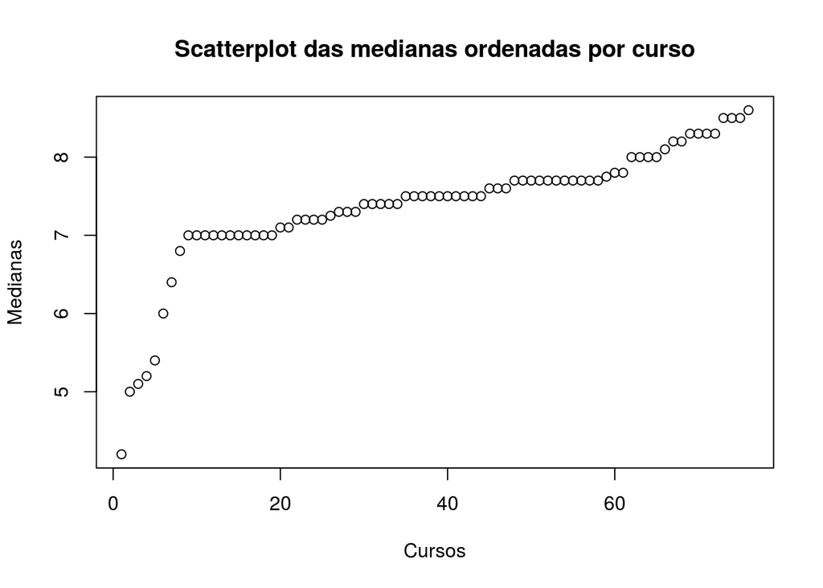

```r
plot(sort(medianByCourse$x), main="Scatterplot das medianas ordenadas por curso", xlab = "Cursos", ylab = "Medianas")
```

> Parte 2

### Em qual curso e em qual período estão as melhores e piores notas?

Como foi definido o uso da mediana para análise dos cursos, podemos ver na consulta abaixo que os valore com maiores e menores médias são os de DIREITO - M e ESTATÍSTICA - D, respectivamente.

```r
maxM <- max(medianByCourse$x)
minM <- min(medianByCourse$x)
medianByCourse[medianByCourse$x == maxM,]
```

```
##        Group.1   x
## 20 DIREITO - M 8.6
```

```r
medianByCourse[medianByCourse$x == minM,]
```

```
##            Group.1   x
## 39 ESTATÍSTICA - D 4.2
```

```r
print(medianByPeriodic[medianByPeriodic$x == max(medianByPeriodic$x),])
```

```
##    Group.1   x
## 1   2002.1 7.7
## 5   2004.1 7.7
## 7   2005.1 7.7
## 8   2005.2 7.7
## 9   2006.1 7.7
## 22  2012.2 7.7
## 23  2013.1 7.7
## 24  2013.2 7.7
## 25  2014.1 7.7
```

### Por que você acha que isso acontece em cada caso?

Isso ocorre devido ao uso da análise pela mediana, que nos diz que, pelas medianas, tanto nos piores e melhores cursos como nos períodos, metade dos alunos alcançam as notas associadas. Como isso, podemos inferir esses resultados das questões avaliadas.

> Parte 3

### Quão desiguais são os notas entre os cursos e os períodos como um todo? Há cursos mais desiguais?

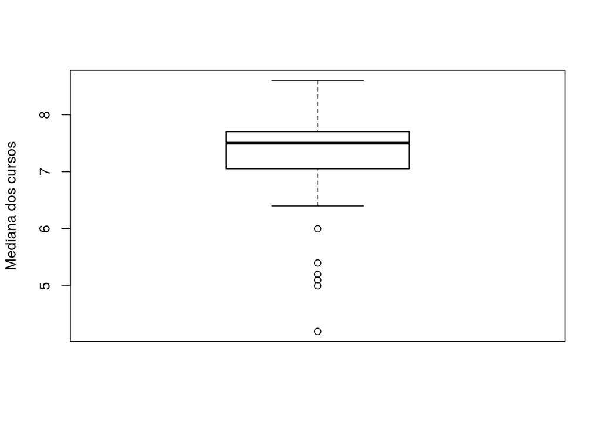

```r
boxplot(medianByCourse$x, ylab = "Mediana dos cursos")
```

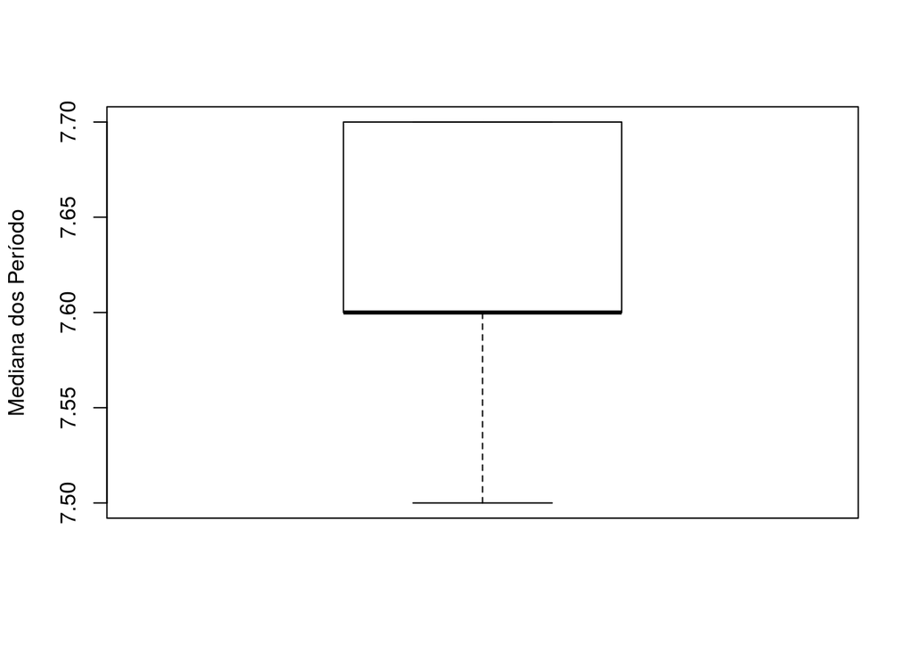

```r
boxplot(medianByPeriodic$x, ylab = "Mediana dos Período")
```

> Parte 4

### Quais unidades acadêmicas estão mais correlacionadas em relação às notas dos alunos?

Verificando a mediana de todos os alunos, com a mediana por centro acadêmico, se verifica que UNID. ACAD. DE EDUCAÇÃO DO CAMPO com 7.6 é o centro que mais se aproxima dos alunos.

```r
unidade <- aggregate(alunos$Media_Disciplina, by=list(alunos$Departamento), FUN=median,na.rm=T)
medianAll <- median(alunos$Media_Disciplina, na.rm = T)
unidade[unidade$x == medianAll,]
```

```
##                             Group.1   x
## 16 UNID. ACAD. DE EDUCAÇÃO DO CAMPO 7.6
```